# 19. Introduction to Spatial Data

## French COVID-19 Data

### Overview

For our next unit, we will be looking at a collection of spatio-temporal data (that is, data with a time component and spatial component) concerning the ongoing COVID-19 pandemic. We will start by looking at data from France, and then move to data from the United States. Today we will introduce tools for working with spatial data. In the next notebook we will see techniques for working with data containing a date variable.

Here are the three French datasets that we will be working with. They contain spatial information, population metadata, and coronavirus numbers at the level of French *départements*. These are geographic areas that are an important political entities in France. There are 101 départements; 96 in mainland Europe and 5 overseas (called the *DOM*, or Départements d’outre-mer).

```r
dept <- read_sf(file.path("data", "france_departement.geojson"))
pop <- read_csv(file.path("data", "france_departement_population.csv"))
covid <- read_csv(file.path("data", "france_departement_covid.csv"))
```

The coronavirus data is stored with one row for each combination of day and département. We have the cumulative number of people who died in each day from COVID-19, the total number currently in hospital, the total number currently in *reanimation* (this is similar to ICU, but not exactly equivalent, so I used the french term here), and the cumulative number of newly recovered. Notice that deceased and recovered are the *total* counts of people who have died or recovered, whereas hospitalised and reanimation are the numbers at that moment of patients in each group. There are columns indicating the number of new hospitalisations and reanimations, but these have many missing data points.

```r
covid
```

```
## # A tibble: 19,998 × 9
##    date       departement departement_name  deceased hospitalised reanimation
##    <date>     <chr>       <chr>                <dbl>        <dbl>       <dbl>
##  1 2020-03-18 01          Ain                      0            2           0
##  2 2020-03-18 02          Aisne                    9            0           0
##  3 2020-03-18 03          Allier                   0            0           0
##  4 2020-03-18 04          Alpes-de-Haute-P…        0            3           1
##  5 2020-03-18 05          Hautes-Alpes             0            8           1
##  6 2020-03-18 06          Alpes-Maritimes          2           25           1
##  7 2020-03-18 07          Ardèche                  0            0           0
##  8 2020-03-18 08          Ardennes                 0            0           0
##  9 2020-03-18 09          Ariège                   0            1           1
## 10 2020-03-18 10          Aube                     0            5           0
## # … with 19,988 more rows, and 3 more variables: recovered <dbl>,
## #   hospitalised_new <dbl>, reanimation_new <dbl>
```

Note that, along with date, either the `departement` or `departement_name` can be used as a primary key for the data. You only need one to uniquely describe a location.

Unlike the United States, France collects and publishes very little demographic data about its citizens. One of the few variables we will be able to look at for each département is its population, which is in the following table:

```r
pop
```

```
## # A tibble: 101 × 2
##    departement population
##    <chr>            <dbl>
##  1 01              643350
##  2 02              534490
##  3 03              337988
##  4 04              163915
##  5 05              141284
##  6 06             1083310
##  7 07              325712
##  8 08              273579
##  9 09              153153
## 10 10              310020
## # … with 91 more rows
```

When working with the county-level U.S. data for project 3, you will have more demographic variables to work with.

### Working with spatial data

We also have loaded spatial data about each département in France in the form of a *simple feature collection*. The data was loaded from a “geojson” file: a plain-text, open specification for describing spatial data and associated metadata. Printing out the dataset shows that it is not too different from an “ordinary” table of data:

```r
dept
```

```
## Simple feature collection with 101 features and 2 fields
## Geometry type: MULTIPOLYGON
## Dimension:     XY
## Bounding box:  xmin: -61.80958 ymin: -21.38936 xmax: 55.83668 ymax: 51.089
## Geodetic CRS:  WGS 84
## # A tibble: 101 × 3
##    departement departement_name                                      geometry
##    <chr>       <chr>                                       <MULTIPOLYGON [°]>
##  1 01          Ain                     (((4.78021 46.17668, 4.78024 46.18905…
##  2 02          Aisne                   (((3.17296 50.01131, 3.17382 50.01186…
##  3 03          Allier                  (((3.03207 46.79491, 3.03424 46.7908,…
##  4 04          Alpes-de-Haute-Provence (((5.67604 44.19143, 5.67817 44.19051…
##  5 05          Hautes-Alpes            (((6.26057 45.12685, 6.26417 45.12641…
##  6 06          Alpes-Maritimes         (((7.06711 43.51365, 7.06665 43.5148,…
##  7 07          Ardèche                 (((4.48313 45.23645, 4.4879 45.23218,…
##  8 08          Ardennes                (((4.23316 49.95775, 4.2369 49.95858,…
##  9 09          Ariège                  (((1.68842 43.27355, 1.69139 43.27173…
## 10 10          Aube                    (((3.41479 48.39027, 3.41555 48.39373…
## # … with 91 more rows
```

Like the `pop` dataset, there is one row for each département. It has sole extra metadata (printed in a different RStudio window) and a special column called `geometry`. The geometry holds all of the information indicating *where* the associate geographic area is on a map.

Most plotting, data manipulation, and modeling functions can be used with a spatial data frame just the same way we used plain data frame. For example, we can do a left join with the population data and slice off the first 96 rows (these are the areas that are in Europe).

```r
dept %>%
  left_join(pop, by = "departement") %>%
  slice(1:96)
```

```
## Simple feature collection with 96 features and 3 fields
## Geometry type: MULTIPOLYGON
## Dimension:     XY
## Bounding box:  xmin: -5.14026 ymin: 41.33363 xmax: 9.55996 ymax: 51.089
## Geodetic CRS:  WGS 84
## # A tibble: 96 × 4
##    departement departement_name                           geometry population
##    <chr>       <chr>                            <MULTIPOLYGON [°]>      <dbl>
##  1 01          Ain                (((4.78021 46.17668, 4.78024 46…     643350
##  2 02          Aisne              (((3.17296 50.01131, 3.17382 50…     534490
##  3 03          Allier             (((3.03207 46.79491, 3.03424 46…     337988
##  4 04          Alpes-de-Haute-Pr… (((5.67604 44.19143, 5.67817 44…     163915
##  5 05          Hautes-Alpes       (((6.26057 45.12685, 6.26417 45…     141284
##  6 06          Alpes-Maritimes    (((7.06711 43.51365, 7.06665 43…    1083310
##  7 07          Ardèche            (((4.48313 45.23645, 4.4879 45.…     325712
##  8 08          Ardennes           (((4.23316 49.95775, 4.2369 49.…     273579
##  9 09          Ariège             (((1.68842 43.27355, 1.69139 43…     153153
## 10 10          Aube               (((3.41479 48.39027, 3.41555 48…     310020
## # … with 86 more rows
```

Notice that the spatial components of the data frame are still present after joining and slicing the data.

Standard **ggplot** functions work to visualise the non-spatial components of our spatial data. To show the spatial component we need to use a unique kind of geometry called `geom_sf`. It will plot the shapes in the dataset (by default from the `geometry` column) over a map. Here is an example of France using our spatial data:

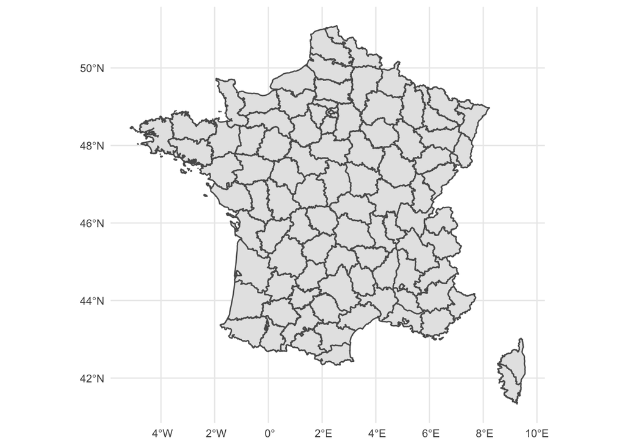

```r
dept %>%
  slice(1:96) %>%
  ggplot() +
    geom_sf()
```

We can control the way the map looks by adjusting the aesthetics, just as with any other geometry:

- color (border color)
- fill (interior color)
- size (width of the border)
- alpha (transparency of the shapes)

Here, we will make the borders very small and show the overall population of each département:

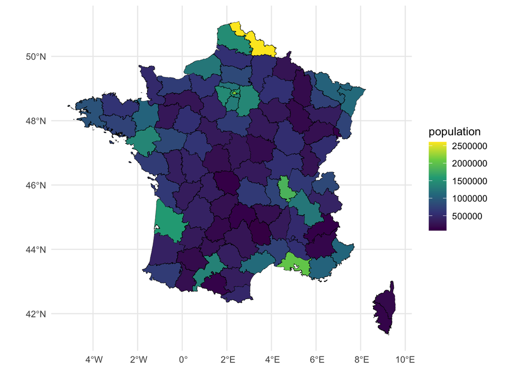

```r
dept %>%
  left_join(pop, by = "departement") %>%
  slice(1:96) %>%
  ggplot() +
    geom_sf(aes(fill = population), color = "black", size = 0.1) +
    scale_fill_viridis_c()
```

You may disagree, but I think that’s a pretty nice map with not too much extra work! While you may be surprised to see this, the largest population is in fact in the Nord département and not Paris (though the latter has a much higher population density).

Two other spatial geometries exist: `geom_sf_text` and `geom_sf_label` for adding labels to a plot. For example, here we can name some of the areas:

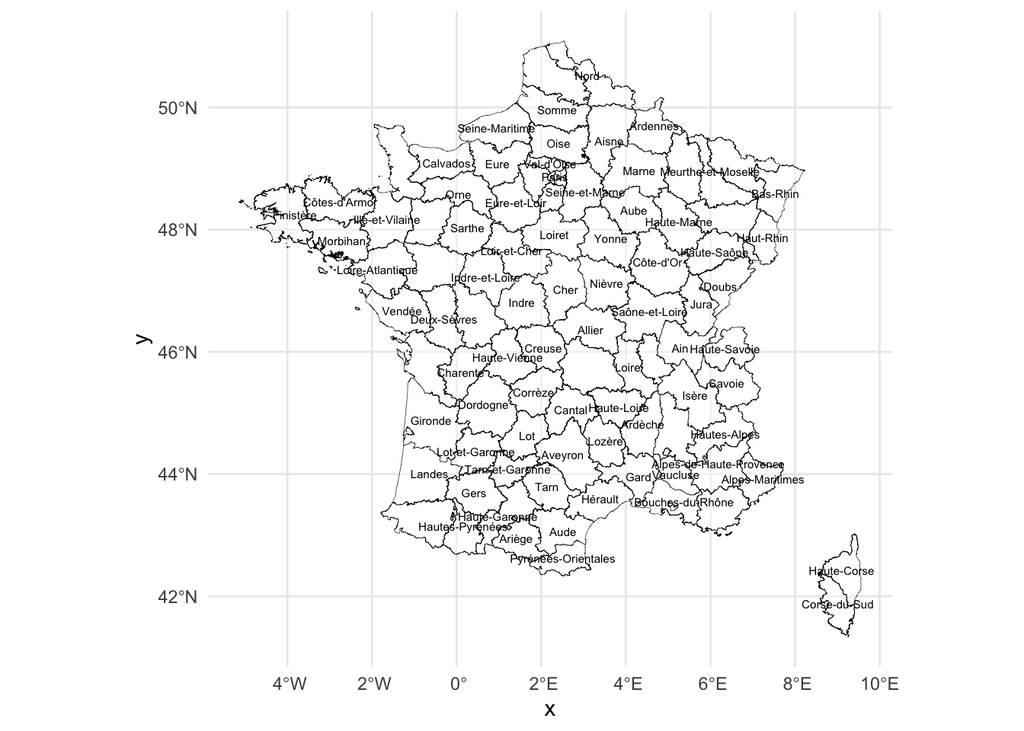

```r
dept %>%
  left_join(pop, by = "departement") %>%
  slice(1:96) %>%
  ggplot() +
    geom_sf(color = "black", fill = "white", alpha = 0.4, size = 0.1) +
    geom_sf_text(aes(label = departement_name), check_overlap = TRUE, size = 2)
```

Note that some areas are not labelled because we set `check_overlap` to `TRUE`.

### Spatial operations

We can also use the spatial information in our dataset to compute metrics about the geometric areas. For example, the function `st_area` computes the total area of each value in the geometry column (two extra functions are needed to convert the output to a usable number of square-kilometers).

```r
dept %>%
  mutate(area = as.numeric(set_units(st_area(geometry), "km^2")))
```

```
## Simple feature collection with 101 features and 3 fields
## Geometry type: MULTIPOLYGON
## Dimension:     XY
## Bounding box:  xmin: -61.80958 ymin: -21.38936 xmax: 55.83668 ymax: 51.089
## Geodetic CRS:  WGS 84
## # A tibble: 101 × 4
##    departement departement_name                                geometry  area
##  * <chr>       <chr>                                 <MULTIPOLYGON [°]> <dbl>
##  1 01          Ain                (((4.78021 46.17668, 4.78024 46.1890… 5771.
##  2 02          Aisne              (((3.17296 50.01131, 3.17382 50.0118… 7388.
##  3 03          Allier             (((3.03207 46.79491, 3.03424 46.7908… 7360.
##  4 04          Alpes-de-Haute-Pr… (((5.67604 44.19143, 5.67817 44.1905… 6981.
##  5 05          Hautes-Alpes       (((6.26057 45.12685, 6.26417 45.1264… 5678.
##  6 06          Alpes-Maritimes    (((7.06711 43.51365, 7.06665 43.5148… 4286.
##  7 07          Ardèche            (((4.48313 45.23645, 4.4879 45.23218… 5554.
##  8 08          Ardennes           (((4.23316 49.95775, 4.2369 49.95858… 5228.
##  9 09          Ariège             (((1.68842 43.27355, 1.69139 43.2717… 4903.
## 10 10          Aube               (((3.41479 48.39027, 3.41555 48.3937… 6010.
## # … with 91 more rows
```

From there, we could join to the population data and compute the population density of each area. We can also use the function `sm_centroid` to compute the lon and lat coordinates of the centroid of each region in our dataset. This is useful for quickly plotting large spatial datasets without needing all the machinery of the spatial geometries (which are great, but can be slow at scale).

```r
dept %>%
  mutate(sm_centroid(geometry))
```

```
## Simple feature collection with 101 features and 4 fields
## Geometry type: MULTIPOLYGON
## Dimension:     XY
## Bounding box:  xmin: -61.80958 ymin: -21.38936 xmax: 55.83668 ymax: 51.089
## Geodetic CRS:  WGS 84
## # A tibble: 101 × 5
##    departement departement_name                          geometry   lon   lat
##  * <chr>       <chr>                           <MULTIPOLYGON [°]> <dbl> <dbl>
##  1 01          Ain               (((4.78021 46.17668, 4.78024 46…  5.35  46.1
##  2 02          Aisne             (((3.17296 50.01131, 3.17382 50…  3.56  49.6
##  3 03          Allier            (((3.03207 46.79491, 3.03424 46…  3.19  46.4
##  4 04          Alpes-de-Haute-P… (((5.67604 44.19143, 5.67817 44…  6.24  44.1
##  5 05          Hautes-Alpes      (((6.26057 45.12685, 6.26417 45…  6.26  44.7
##  6 06          Alpes-Maritimes   (((7.06711 43.51365, 7.06665 43…  7.12  43.9
##  7 07          Ardèche           (((4.48313 45.23645, 4.4879 45.…  4.42  44.8
##  8 08          Ardennes          (((4.23316 49.95775, 4.2369 49.…  4.64  49.6
##  9 09          Ariège            (((1.68842 43.27355, 1.69139 43…  1.50  42.9
## 10 10          Aube              (((3.41479 48.39027, 3.41555 48…  4.16  48.3
## # … with 91 more rows
```

We can also use the `st_transform` function to *project* the coordinates in our dataset into a coordinate system to best plot our data. Each coordinate system uses a numeric code called is [EPSG](https://epsg.io/) code; you can look up the best one for the region you are interested in. For example, for Metropolitain France we might use [EPSG:3943](https://epsg.io/3943). This can be done with the following code.

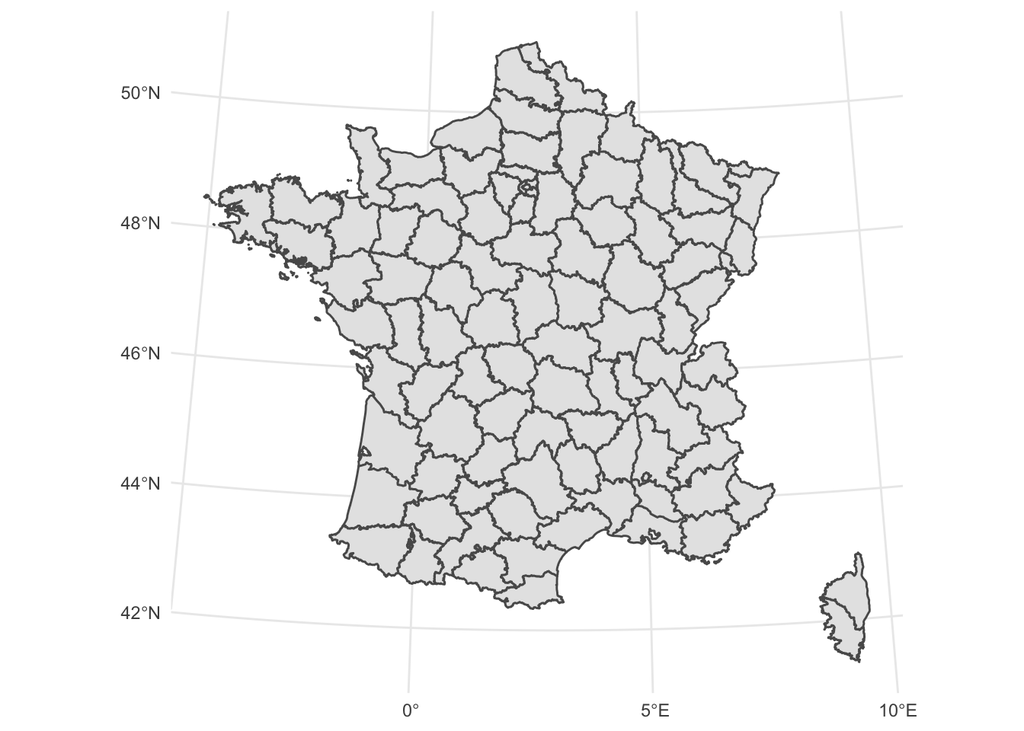

```r
dept %>%
  slice(1:96) %>%
  st_transform(3943) %>%
  ggplot() +
    geom_sf()
```

Note that this create a slightly more accurate map of the data and that the y-axis and lines of longitude are no-longer parallel.

Likewise, for Guadeloupe, Martinique and Guyane we might use [EPSG:2972](https://epsg.io/2972):

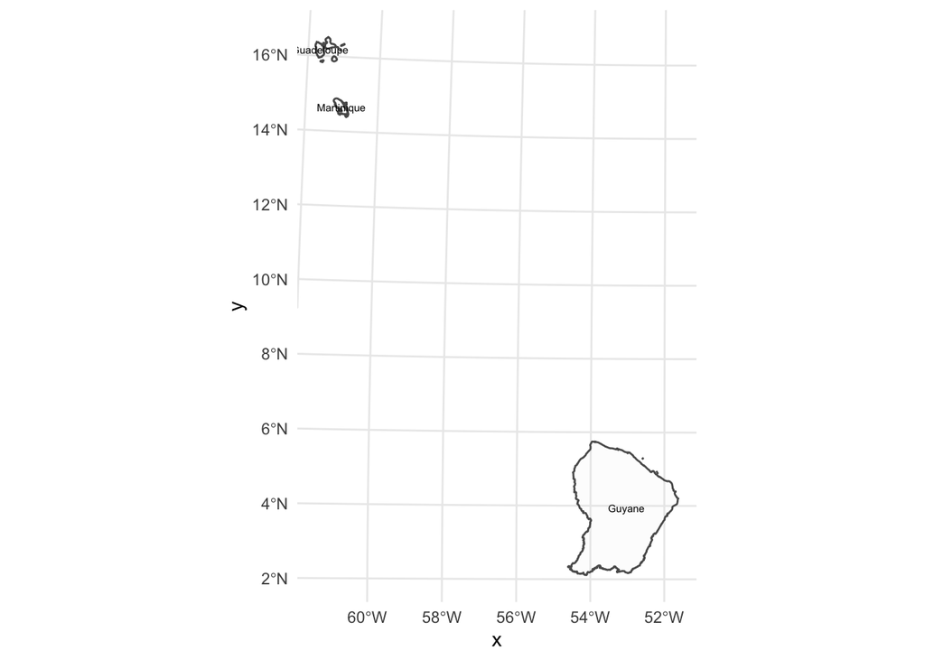

```r
dept %>%
  slice(97:99) %>%
  st_transform(2972) %>%
  ggplot() +
    geom_sf(alpha = 0.1) +
    geom_sf_text(aes(label = departement_name), size = 2)
```

And for La Réunion and Mayotte we might use [EPSG:5879](https://epsg.io/5879):

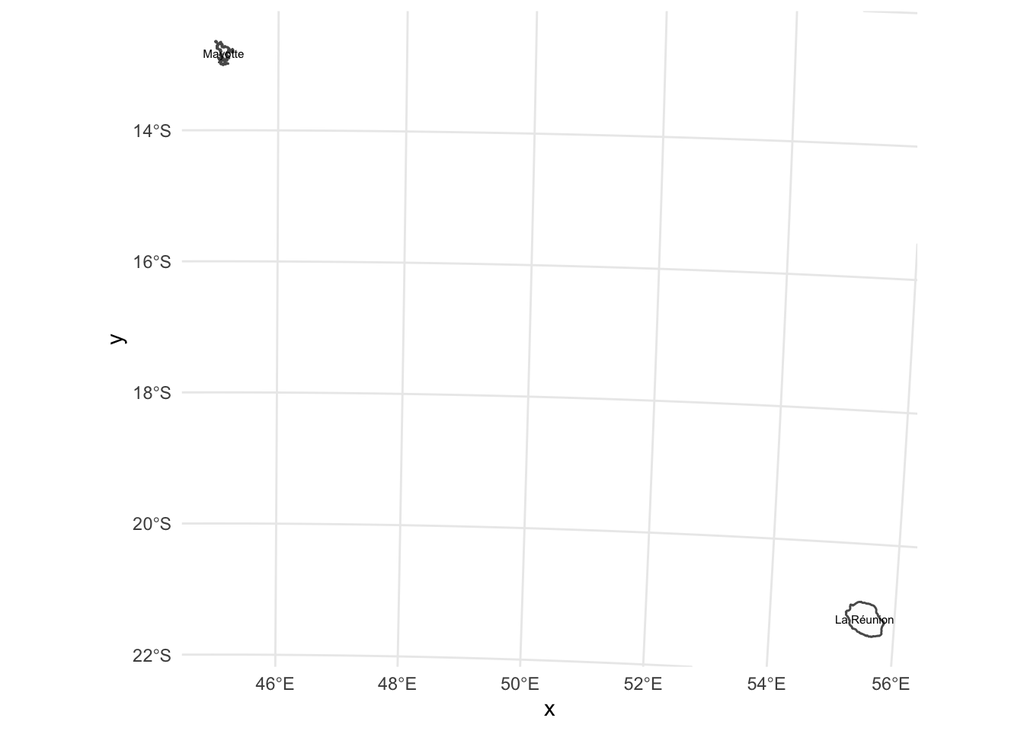

```r
dept %>%
  slice(100:101) %>%
  st_transform(5879) %>%
  ggplot() +
    geom_sf(alpha = 0.1) +
    geom_sf_text(aes(label = departement_name), size = 2)
```

We will see that these projections help particularly when using large regions like the U.S.; they are also particularly useful for projecting data near the North or South Pole.